# Spatial analyses of 2020-21 excess mortality in CH

Geodata preparation

# Data sources

## BfS geodata 2021

[Generalisierte Gemeindegrenzen: Geodaten](https://www.bfs.admin.ch/bfs/de/home/dienstleistungen/geostat/geodaten-bundesstatistik/administrative-grenzen/generalisierte-gemeindegrenzen.assetdetail.17964056.html).

Contains three versions of data:

> “Generalisierte Gemeindegrenzen, Stand 01.01.2021 & 18.04.2021 & 01.07.2021”

**Using `01.07` release.**

```r
download.file(url = "https://www.bfs.admin.ch/bfsstatic/dam/assets/17964056/master",
              destfile = "data-raw/BfS/ag-b-00.03-875-gg21.zip",
              method = "curl")

unzip("data-raw/BfS/ag-b-00.03-875-gg21.zip", exdir = "data-raw/BfS/ag-b-00.03-875-gg21")

unlink("data-raw/BfS/ag-b-00.03-875-gg21.zip")
unlink("data-raw/BfS/ag-b-00.03-875-gg21/txt", recursive = TRUE)
unlink("data-raw/BfS/ag-b-00.03-875-gg21/kmz", recursive = TRUE)
unlink("data-raw/BfS/ag-b-00.03-875-gg21/ggg_2021-LV03", recursive = TRUE)
unlink("data-raw/BfS/ag-b-00.03-875-gg21/ggg_2021-LV95/ggg_2021-LV95.gdb", recursive = TRUE)
```

```r
gg21 <-
  st_read("data-raw/BfS/ag-b-00.03-875-gg21/ggg_2021-LV95/shp/g1g21_01072021.shp",
          as_tibble = TRUE) %>%
  st_set_crs(2056)
kt21 <-
  st_read("data-raw/BfS/ag-b-00.03-875-gg21/ggg_2021-LV95/shp/g1k21.shp",
          as_tibble = TRUE)
se21 <-
  st_read("data-raw/BfS/ag-b-00.03-875-gg21/ggg_2021-LV95/shp/g1s21.shp",
          as_tibble = TRUE) %>%
  filter(GMDNAME != "Lago di Como")
```

### Canton

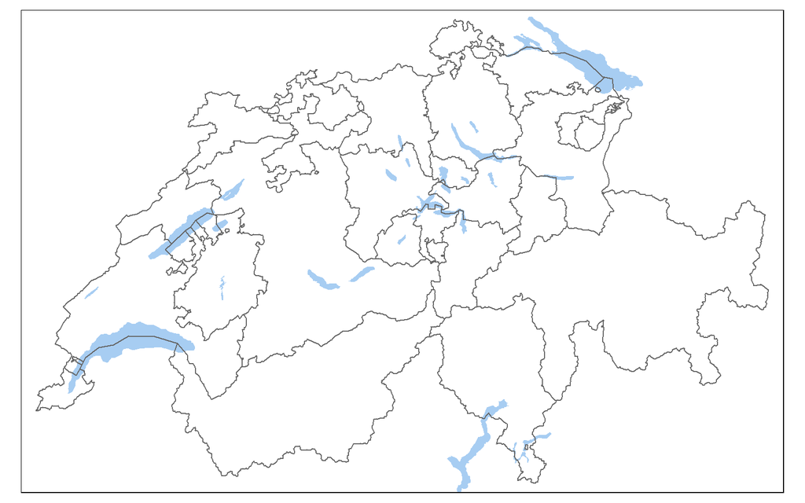

### Municipality

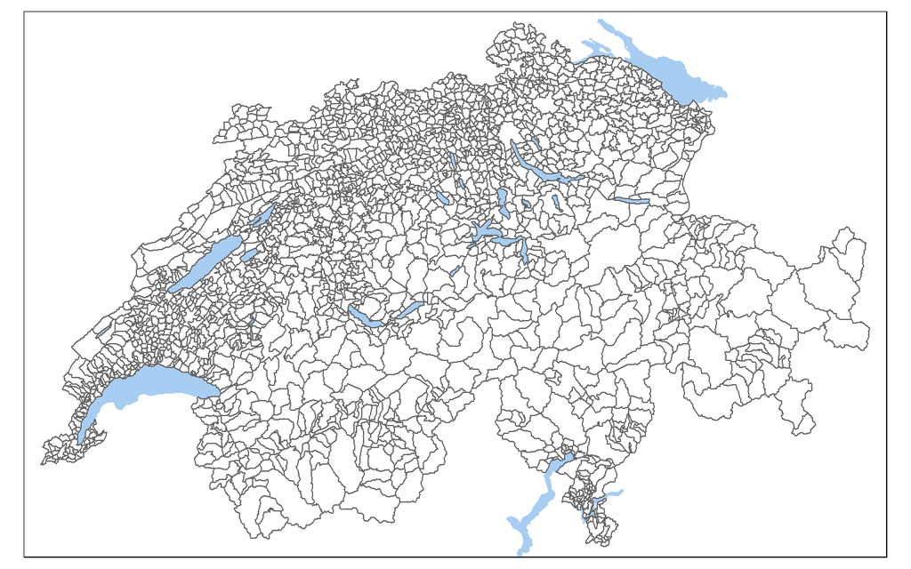

## swisstopo geodata 2021

`swissBOUNDARIES3D` data available from [here](https://www.swisstopo.admin.ch/de/geodata/landscape/boundaries3d.html). Also exist in July versions.

```r
download.file(url = "https://data.geo.admin.ch/ch.swisstopo.swissboundaries3d/swissboundaries3d_2021-07/swissboundaries3d_2021-07_2056_5728.shp.zip",
              destfile = "data-raw/swisstopo/swissboundaries3d_2021-07_2056_5728.shp.zip",
              method = "curl")

unzip("data-raw/swisstopo/swissboundaries3d_2021-07_2056_5728.shp.zip",
      exdir = "data-raw/swisstopo/swissboundaries3d_2021-07_2056_5728")

unlink("data-raw/swisstopo/swissboundaries3d_2021-01_2056_5728.shp.zip")
```

```r
st_gg21 <-
  st_read("data-raw/swisstopo/swissboundaries3d_2021-07_2056_5728/SHAPEFILE_LV95_LN02/swissBOUNDARIES3D_1_3_TLM_HOHEITSGEBIET.shp",
          as_tibble = TRUE) %>%
  st_zm(drop = TRUE, what = "ZM")
st_kt21 <-
  st_read("data-raw/swisstopo/swissboundaries3d_2021-07_2056_5728/SHAPEFILE_LV95_LN02/swissBOUNDARIES3D_1_3_TLM_KANTONSGEBIET.shp",
          as_tibble = TRUE) %>%
  st_zm(drop = TRUE, what = "ZM")
```

## Important differences

### Resolution

swisstopo borders (in blue below) are larger in size (and slower to plot) but offer better resolution and will be used for certain spatial operations (like linking to SEP) whereas BfS data are smaller in size and easier to plot. Example of municipality Bern:

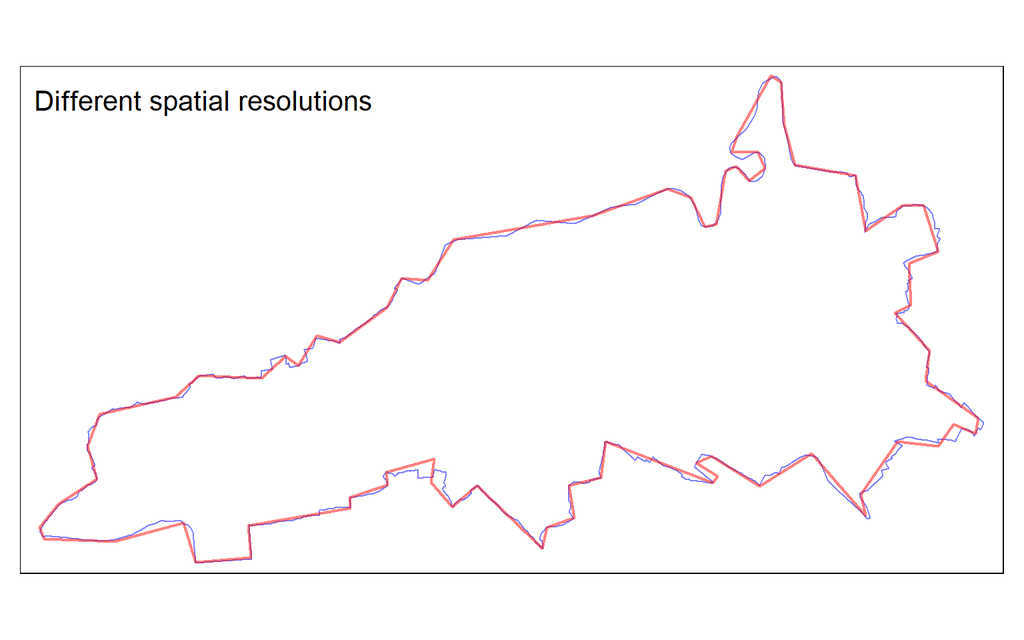

### Water bodies

Additionally datasets differ in terms of conceptualization of the boundaries of water bodies. BfS data reach the shore of the lake, whereas swisstopo extends them over lakes. Example of municipality *Delley-Portalban* by the *Lac de Neuchâtel*:

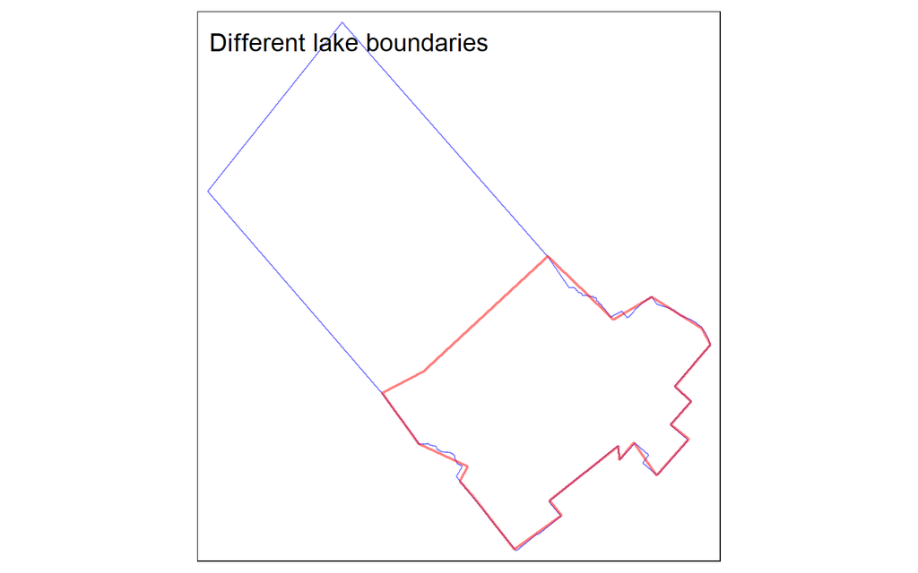

### Multipart features

BfS stores data as `MULTIPOLYGON`. In such case municipality split over several disconnected areas is stored as *single record*. Example of municipality Monthey which consists of four separate areas:

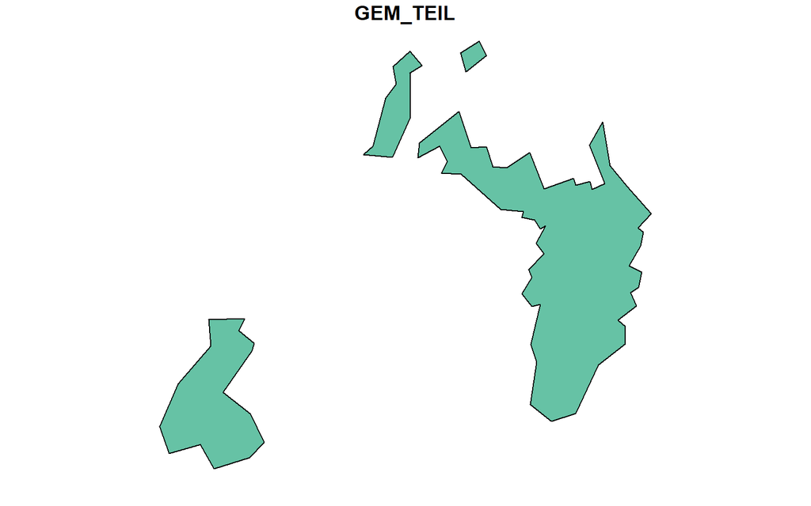

The same municipality in swisstopo data is stored as `POLYGON` type. In such case it will be represented as *four separate records* (four individual polygons) instead of one.

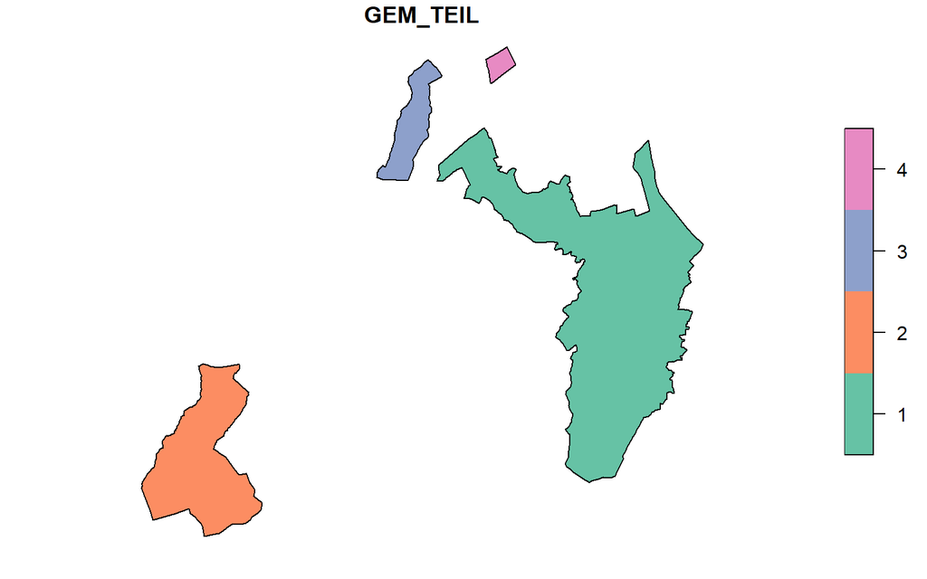

That might have some implications in terms of spatial operations (maybe contiguity too?). Data can easily be converted between types if needed.

# Preparations

## Non-residential municipalities

Excluding municipalities without residents:

- `Staatswald Galm`,
- `Comunanza Cadenazzo/Monteceneri`
- `Comunanza Capriasca/Lugano`

```r
gg21 %>%
  st_drop_geometry() %>%
  filter(GMDNR %in% c(2391, 5391, 5394)) %>%
  select(GMDNAME)
```

```
# A tibble: 3 x 1
  GMDNAME
  <chr>
1 Staatswald Galm
2 C'za Cadenazzo/Monteceneri
3 C'za Capriasca/Lugano
```

## Labour market areas 2018

### Data sources

More info [here](https://www.bfs.admin.ch/bfs/de/home/aktuell/neue-veroeffentlichungen.gnpdetail.2019-0439.html).

```r
raum <- read_xlsx("data-raw/BfS/Raumgliederungen.xlsx",
                  skip = 1) %>%
  remove_empty(c("rows", "cols")) %>% clean_names() %>%
  filter(! is.na(bfs_gde_nummer)) %>%
  rename(GMDNR = bfs_gde_nummer,
         GMDNAME = gemeindename,
         KTNAME = kanton,
         BZNAME = bezirksname,
         ARGRNR = arbeitsmarktgrossregionen_2018,
         ARNR = arbeitsmarktregionen_2018) %>%
  select(GMDNR, GMDNAME,
         KTNAME, BZNAME,
         ARGRNR, ARNR) %>%
  left_join(
    read_xlsx("data-raw/BfS/Raumgliederungen.xlsx",
              skip = 1, sheet = "CH1+CL_GBAE+2018.0") %>%
      rename(
        ARGRNR = Code,
        ARGRNAME = Label)
  ) %>%
  left_join(
    read_xlsx("data-raw/BfS/Raumgliederungen.xlsx",
              skip = 1, sheet = "CH1+CL_BAE+2018.0") %>%
      rename(
        ARNR = Code,
        ARNAME = Label)
  ) %>%
  relocate(ARGRNAME, .after = ARGRNR) %>%
  relocate(ARNAME, .after = ARNR) %>%
  mutate(border = if_else(ARNAME %in% c("Schaffhausen", "Basel",
                                        "Delémont", "Porrentruy", "Saignelégier–Le Noirmont", "La Chaux-de-Fonds",
                                        "Le Chenit", "Genève",
                                        "Locarno", "Lugano"),
                          1, 0))
```

### Preps

List of regions was merged on the basis of municipality number and then these municipalities were aggregated.

```r
argr_21 <- gg21 %>%
  left_join(raum) %>%
  group_by(ARGRNR) %>%
  summarise(ARGRNR = first(ARGRNR),
            ARGRNAME = first(ARGRNAME)) %>%
  st_cast("MULTIPOLYGON")

ar_21 <- gg21 %>%
  left_join(raum) %>%
  group_by(ARNR) %>%
  summarise(ARNR = first(ARNR),
            ARNAME = first(ARNAME),
            border = first(border)) %>%
  st_cast("MULTIPOLYGON")
```

Dissolving of BfS data via R was not perfect and manual corrections were implemented in QGIS software.

```r
# st_write(argr_21, "data/geo/argr_21_cor.shp", delete_dsn = TRUE)
# st_write(ar_21, "data/geo/ar_21_cor.shp", delete_dsn = TRUE)

argr_21_cor <- st_read("data/geo/argr_21_cor.shp") %>%
  select(-ARGRNAME) %>%
  left_join(raum %>% select(ARGRNR, ARGRNAME)) %>%
  group_by(ARGRNR) %>%
  summarise(ARGRNR = first(ARGRNR),
            ARGRNAME = first(ARGRNAME)) %>%
  st_cast("MULTIPOLYGON")
ar_21_cor <- st_read("data/geo/ar_21_cor.shp") %>%
  select(-ARNAME) %>%
  left_join(raum %>% select(ARNR, ARNAME, border)) %>%
  group_by(ARNR) %>%
  summarise(ARNR = first(ARNR),
            ARNAME = first(ARNAME),
            border = first(border)) %>%
  st_cast("MULTIPOLYGON")
write_rds(argr_21_cor, "data/geo/argr_21_cor.Rds")
write_rds(ar_21_cor, "data/geo/ar_21_cor.Rds")
```

Dissolve in R using swisstopo data was all fine.

```r
# same for swisstopo
# removing '-' from names which causes problems with writing shp
st_argr_21 <- st_gg21 %>%
  left_join(raum) %>%
  group_by(ARGRNR) %>%
  summarise(ARGRNR = first(ARGRNR),
            ARGRNAME = first(ARGRNAME)) %>%
  st_cast("MULTIPOLYGON") %>%
  mutate(ARGRNAME = str_replace_all(ARGRNAME, "–", " "))

st_ar_21 <- st_gg21 %>%
  left_join(raum) %>%
  group_by(ARNR) %>%
  summarise(ARNR = first(ARNR),
            ARNAME = first(ARNAME),
            border = first(border)) %>%
  st_cast("MULTIPOLYGON") %>%
  mutate(ARNAME = str_replace_all(ARNAME, "–", " "))
```

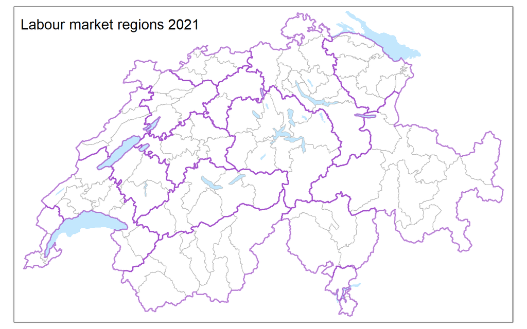

### Border regions

Defined on the basis of [this map](https://www.bfs.admin.ch/bfs/de/home/aktuell/neue-veroeffentlichungen.assetdetail.8706500.html). Linked by name of the region since some codes seemed to be out of date? (ie. Basel).

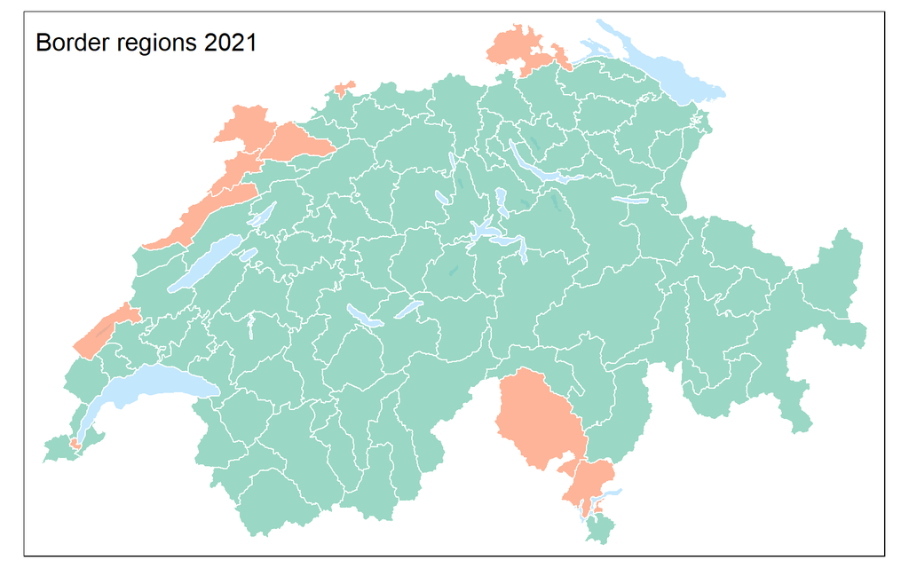

|  | ARNR | ARNAME |
| --- | --- | --- |
| 1 | 01012 | Genève |
| 2 | 02010 | Le Chenit |
| 3 | 03020 | La Chaux-de-Fonds |
| 4 | 03040 | Saignelégier–Le Noirmont |
| 5 | 05010 | Porrentruy |
| 6 | 05040 | Delémont |
| 7 | 08013 | Basel |
| 8 | 12020 | Schaffhausen |
| 9 | 13020 | Locarno |
| 10 | 14010 | Lugano |

The same typology can be applied to municipalities:

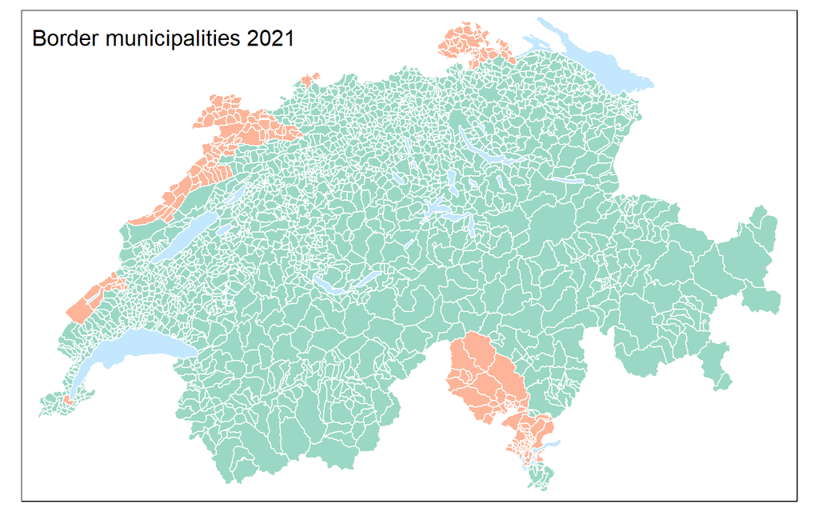

|  | GMDNAME | BZNAME | ARGRNAME | ARNAME |
| --- | --- | --- | --- | --- |
| 1 | Benken (ZH) | Andelfingen | Region Zürich | Schaffhausen |
| 2 | Dachsen | Andelfingen | Region Zürich | Schaffhausen |
| 3 | Feuerthalen | Andelfingen | Region Zürich | Schaffhausen |
| 4 | Flurlingen | Andelfingen | Region Zürich | Schaffhausen |
| 5 | Laufen-Uhwiesen | Andelfingen | Region Zürich | Schaffhausen |
| 6 | Marthalen | Andelfingen | Region Zürich | Schaffhausen |
| 7 | Rheinau | Andelfingen | Region Zürich | Schaffhausen |
| 8 | Trüllikon | Andelfingen | Region Zürich | Schaffhausen |
| 9 | Cormoret | Jura bernois | Region Neuenburg | La Chaux-de-Fonds |
| 10 | Cortébert | Jura bernois | Region Neuenburg | La Chaux-de-Fonds |

[output cut: 186 more lines]

```r
gg21 %>% left_join(raum %>% select(GMDNR, KTNAME, BZNAME,
                                   ARGRNR, ARGRNAME, ARNR, ARNAME,
                                   border)) %>%
  relocate(geometry, .after = last_col()) %>%
  write_rds("data/BfS/gg21.Rds")

st_gg21 %>% left_join(raum %>% select(GMDNR, KTNAME, BZNAME,
                                      ARGRNR, ARGRNAME, ARNR, ARNAME,
                                      border)) %>%
  relocate(geometry, .after = last_col()) %>%
  write_rds("data/swisstopo/st_gg21.Rds")
```

# Municipality boundaries mutations

Using `Gemeindestand - Stand vom 01.07.2021.xlsx` from [here](https://www.agvchapp.bfs.admin.ch/de/home) we can identify municipalities with changes during the study period.

```r
histcomm <- read_xlsx("data-raw/BfS/Mutierte_Gemeinden_20150101_bis_20210701.xlsx",
                      col_types = c("numeric", "text", "numeric",
                                    "numeric", "text", "text", "numeric",
                                    "numeric", "text", "text"),
                      skip = 1) %>%
  remove_empty(c("rows", "cols")) %>% clean_names() %>%
  mutate(datum_der_aufnahme = ymd(datum_der_aufnahme)) %>%
  arrange(desc(datum_der_aufnahme), gemeindename_5) %>%
  rename(kanton_old = kanton_2,
         bezirks_num_old = bezirks_nummer_3,
         bfs_gde_num_old = bfs_gde_nummer_4,
         gemeindename_old = gemeindename_5,
         kanton_new = kanton_6,
         bezirks_num_new = bezirks_nummer_7,
         bfs_gde_num_new = bfs_gde_nummer_8,
         gemeindename_new = gemeindename_9)
```

There were 64 municipalities with changes recorded in `2015-01-01` - `2021-07-01` period.

Here is list of changes from `2020-01-01` onwards that could affect other data that date for instance refer to `2020-12-31`:

|  | mutationsnummer | kanton_old | bfs_gde_num_old | gemeindename_old | bfs_gde_num_new | gemeindename_new | datum_der_aufnahme |
| --- | --- | --- | --- | --- | --- | --- | --- |
| 1 | 3955 | VD | 5421 | Apples | 5656 | Hautemorges | 2021-07-01 |
| 2 | 3956 | VD | 5513 | Bioley-Orjulaz | 5511 | Assens | 2021-07-01 |
| 3 | 3955 | VD | 5625 | Bussy-Chardonney | 5656 | Hautemorges | 2021-07-01 |
| 4 | 3955 | VD | 5478 | Cottens (VD) | 5656 | Hautemorges | 2021-07-01 |
| 5 | 3955 | VD | 5494 | Pampigny | 5656 | Hautemorges | 2021-07-01 |
| 6 | 3955 | VD | 5644 | Reverolle | 5656 | Hautemorges | 2021-07-01 |
| 7 | 3955 | VD | 5500 | Sévery | 5656 | Hautemorges | 2021-07-01 |
| 8 | 3954 | TI | 5178 | Croglio | 5239 | Tresa | 2021-04-18 |
| 9 | 3954 | TI | 5202 | Monteggio | 5239 | Tresa | 2021-04-18 |
| 10 | 3954 | TI | 5213 | Ponte Tresa | 5239 | Tresa | 2021-04-18 |

[output cut: 34 more lines]

Luckily only few changes occurred after `2021-01-01` and it was a fusion which is easier to handle.